# Bank_Marketing_Subscription_Prediction

## 1 - Abstract:

The data is related with direct marketing campaigns (phone calls) of a Portuguese banking institution. The classification goal is to predict if the client will subscribe a term deposit (variable y).

- age (numeric)
- job : type of job (categorical: 'admin.','blue-collar','entrepreneur','housemaid','management','retired','self-employed','services','student','technician','unemployed','unknown')
- marital : marital status (categorical: 'divorced','married','single','unknown'; note: 'divorced' means divorced or widowed)
- education (categorical: 'basic.4y','basic.6y','basic.9y','high.school','illiterate','professional.course','university.degree','unknown')
- default: has credit in default? (categorical: 'no','yes','unknown')
- housing: has housing loan? (categorical: 'no','yes','unknown')
- loan: has personal loan? (categorical: 'no','yes','unknown')
- contact: contact communication type (categorical: 'cellular','telephone')
- month: last contact month of year (categorical: 'jan', 'feb', 'mar', ..., 'nov', 'dec')
- day_of_week: last contact day of the week (categorical: 'mon','tue','wed','thu','fri')
- duration: last contact duration, in seconds (numeric). Important note: this attribute highly affects the output target (e.g., if duration=0 then y='no'). Yet, the duration is not known before a call is performed. Also, after the end of the call y is obviously known. Thus, this input should only be included for benchmark purposes and should be discarded if the intention is to have a realistic predictive model.
- campaign: number of contacts performed during this campaign and for this client (numeric, includes last contact)
- pdays: number of days that passed by after the client was last contacted from a previous campaign (numeric; 999 means client was not previously contacted)
- previous: number of contacts performed before this campaign and for this client (numeric)
- poutcome: outcome of the previous marketing campaign (categorical: 'failure','nonexistent','success')
- emp.var.rate: employment variation rate - quarterly indicator (numeric)
- cons.price.idx: consumer price index - monthly indicator (numeric)
- cons.conf.idx: consumer confidence index - monthly indicator (numeric)
- euribor3m: euribor 3 month rate - daily indicator (numeric)
- nr.employed: number of employees - quarterly indicator (numeric)

Output variable (desired target): 21 - y - has the client subscribed a term deposit? (binary: 'yes','no')

```python
import pandas as pd
import numpy as np
import pandas_profiling
import pixiedust
```

```
Pixiedust database opened successfully
```

[figure not shown]

Pixiedust version 1.1.17

```python
df_bank_full_data = pd.read_csv("../data/bank-additional/bank-additional-full.csv", sep=";")
```

```python
df_bank_full_data.head()
```

|  | age | job | marital | education | default | housing | loan | contact | month | day_of_week | ... | campaign | pdays | previous | poutcome | emp.var.rate | cons.price.idx | cons.conf.idx | euribor3m | nr.employed | y |
| --- | --- | --- | --- | --- | --- | --- | --- | --- | --- | --- | --- | --- | --- | --- | --- | --- | --- | --- | --- | --- | --- |
| 0 | 56 | housemaid | married | basic.4y | no | no | no | telephone | may | mon | ... | 1 | 999 | 0 | nonexistent | 1.1 | 93.994 | -36.4 | 4.857 | 5191.0 | no |
| 1 | 57 | services | married | high.school | unknown | no | no | telephone | may | mon | ... | 1 | 999 | 0 | nonexistent | 1.1 | 93.994 | -36.4 | 4.857 | 5191.0 | no |
| 2 | 37 | services | married | high.school | no | yes | no | telephone | may | mon | ... | 1 | 999 | 0 | nonexistent | 1.1 | 93.994 | -36.4 | 4.857 | 5191.0 | no |
| 3 | 40 | admin. | married | basic.6y | no | no | no | telephone | may | mon | ... | 1 | 999 | 0 | nonexistent | 1.1 | 93.994 | -36.4 | 4.857 | 5191.0 | no |
| 4 | 56 | services | married | high.school | no | no | yes | telephone | may | mon | ... | 1 | 999 | 0 | nonexistent | 1.1 | 93.994 | -36.4 | 4.857 | 5191.0 | no |

5 rows × 21 columns

## We can see there is no missing data in the dataset.

```python
df_bank_full_data.info()
```

```
<class 'pandas.core.frame.DataFrame'>
RangeIndex: 41188 entries, 0 to 41187
Data columns (total 21 columns):
age               41188 non-null int64
job               41188 non-null object
marital           41188 non-null object
education         41188 non-null object
default           41188 non-null object
housing           41188 non-null object
loan              41188 non-null object
contact           41188 non-null object
month             41188 non-null object
day_of_week       41188 non-null object
duration          41188 non-null int64
campaign          41188 non-null int64
pdays             41188 non-null int64
previous          41188 non-null int64
poutcome          41188 non-null object
emp.var.rate      41188 non-null float64
cons.price.idx    41188 non-null float64
cons.conf.idx     41188 non-null float64
euribor3m         41188 non-null float64
nr.employed       41188 non-null float64
y                 41188 non-null object
dtypes: float64(5), int64(5), object(11)
memory usage: 6.6+ MB
```

```python
df_bank_full_data.columns
```

```
Index(['age', 'job', 'marital', 'education', 'default', 'housing', 'loan',
       'contact', 'month', 'day_of_week', 'duration', 'campaign', 'pdays',
       'previous', 'poutcome', 'emp.var.rate', 'cons.price.idx',
       'cons.conf.idx', 'euribor3m', 'nr.employed', 'y'],
      dtype='object')
```

```python
df_bank_full_data.y.value_counts()
```

```
no     36548
yes     4640
Name: y, dtype: int64
```

## Find the correration between columns

```python
df_bank_full_data.corr()
```

|  | age | duration | campaign | pdays | previous | emp.var.rate | cons.price.idx | cons.conf.idx | euribor3m | nr.employed |
| --- | --- | --- | --- | --- | --- | --- | --- | --- | --- | --- |
| age | 1.000000 | -0.000866 | 0.004594 | -0.034369 | 0.024365 | -0.000371 | 0.000857 | 0.129372 | 0.010767 | -0.017725 |
| duration | -0.000866 | 1.000000 | -0.071699 | -0.047577 | 0.020640 | -0.027968 | 0.005312 | -0.008173 | -0.032897 | -0.044703 |
| campaign | 0.004594 | -0.071699 | 1.000000 | 0.052584 | -0.079141 | 0.150754 | 0.127836 | -0.013733 | 0.135133 | 0.144095 |
| pdays | -0.034369 | -0.047577 | 0.052584 | 1.000000 | -0.587514 | 0.271004 | 0.078889 | -0.091342 | 0.296899 | 0.372605 |
| previous | 0.024365 | 0.020640 | -0.079141 | -0.587514 | 1.000000 | -0.420489 | -0.203130 | -0.050936 | -0.454494 | -0.501333 |
| emp.var.rate | -0.000371 | -0.027968 | 0.150754 | 0.271004 | -0.420489 | 1.000000 | 0.775334 | 0.196041 | 0.972245 | 0.906970 |
| cons.price.idx | 0.000857 | 0.005312 | 0.127836 | 0.078889 | -0.203130 | 0.775334 | 1.000000 | 0.058986 | 0.688230 | 0.522034 |
| cons.conf.idx | 0.129372 | -0.008173 | -0.013733 | -0.091342 | -0.050936 | 0.196041 | 0.058986 | 1.000000 | 0.277686 | 0.100513 |
| euribor3m | 0.010767 | -0.032897 | 0.135133 | 0.296899 | -0.454494 | 0.972245 | 0.688230 | 0.277686 | 1.000000 | 0.945154 |
| nr.employed | -0.017725 | -0.044703 | 0.144095 | 0.372605 | -0.501333 | 0.906970 | 0.522034 | 0.100513 | 0.945154 | 1.000000 |

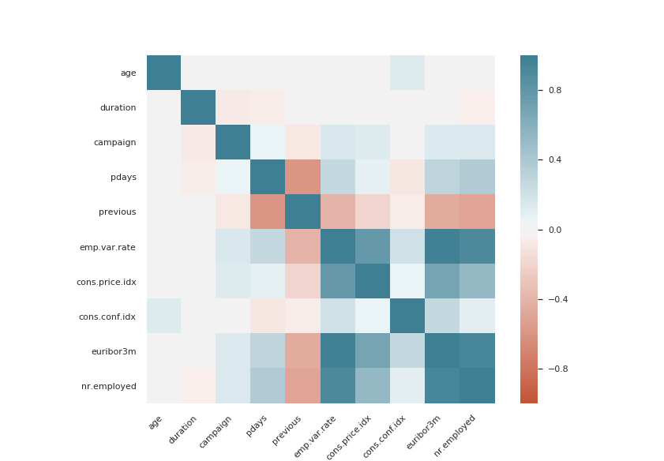

```python
%matplotlib notebook
from string import ascii_letters
import numpy as np
import pandas as pd
import seaborn as sns
import matplotlib.pyplot as plt

sns.set(style="white")

corr = df_bank_full_data.corr()

ax = sns.heatmap(
    corr,
    vmin=-1, vmax=1, center=0,
    cmap=sns.diverging_palette(20, 220, n=200),
    square=True
)
ax.set_xticklabels(
    ax.get_xticklabels(),
    rotation=45,
    horizontalalignment='right'
);
```

```python
#profile = df_bank_full_data.profile_report(title='Pandas Profiling Report', plot={'histogram': {'bins': 8}})
#profile.to_file(output_file="output.html")
```

*Hey, there's something awesome here! To see it, open this notebook outside GitHub, in a viewer like Jupyter*

Term deposit Subscribe distribution (Marital status wise)

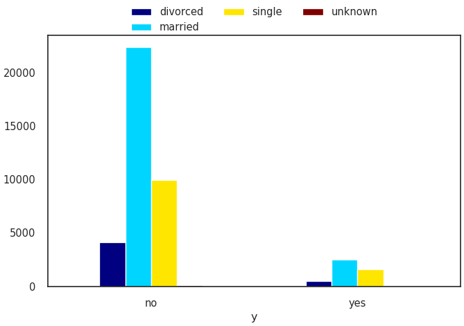

```python
display(df_bank_full_data)
```

*Hey, there's something awesome here! To see it, open this notebook outside GitHub, in a viewer like Jupyter*

Day-of_week wise Subscription convergence distributtion

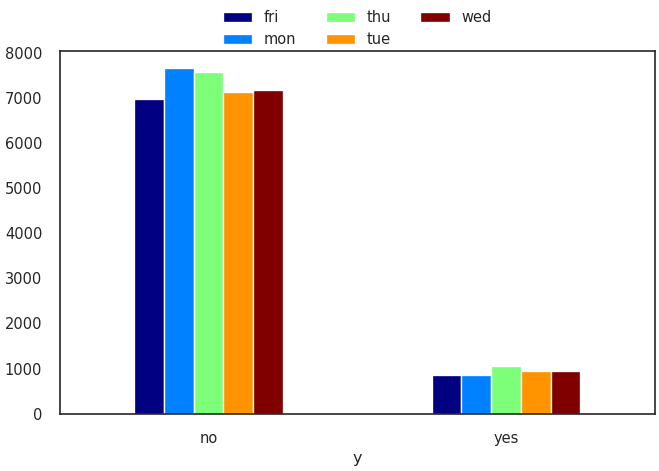

```python
display(df_bank_full_data)
```

*Hey, there's something awesome here! To see it, open this notebook outside GitHub, in a viewer like Jupyter*

Monthly wise Subscription Convergence distribution

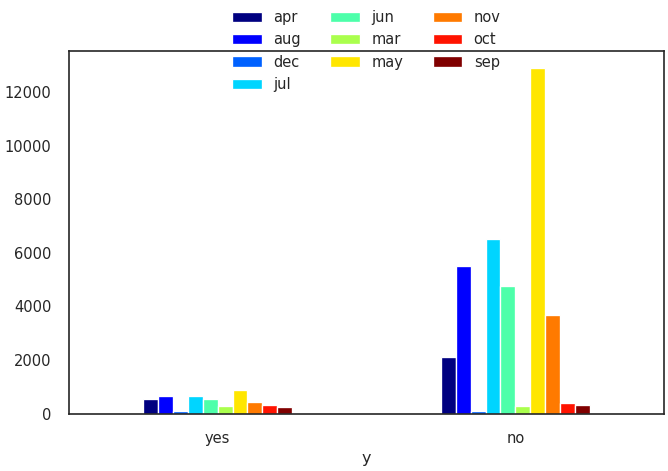

```python
display(df_bank_full_data)
```

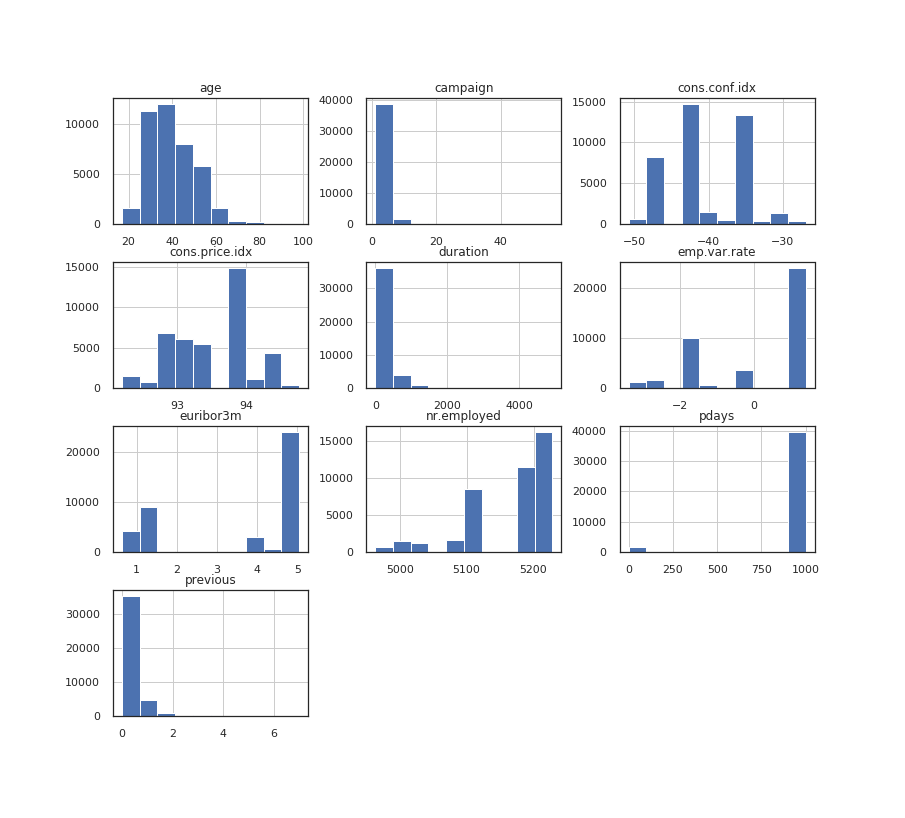

```
array([[<matplotlib.axes._subplots.AxesSubplot object at 0x7fced7e9f710>,
      dtype=object)
```

```python
df_bank_full_data.hist(bins=10)
```

## Box-plot conclusion

- We can see that the 'duration' attribute has a lot of outliers.

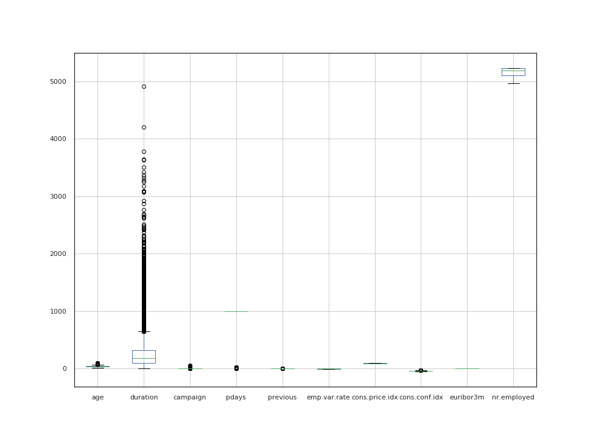

```python
%matplotlib notebook
df_bank_full_data.boxplot()
```

## Feature - Target class Relationship

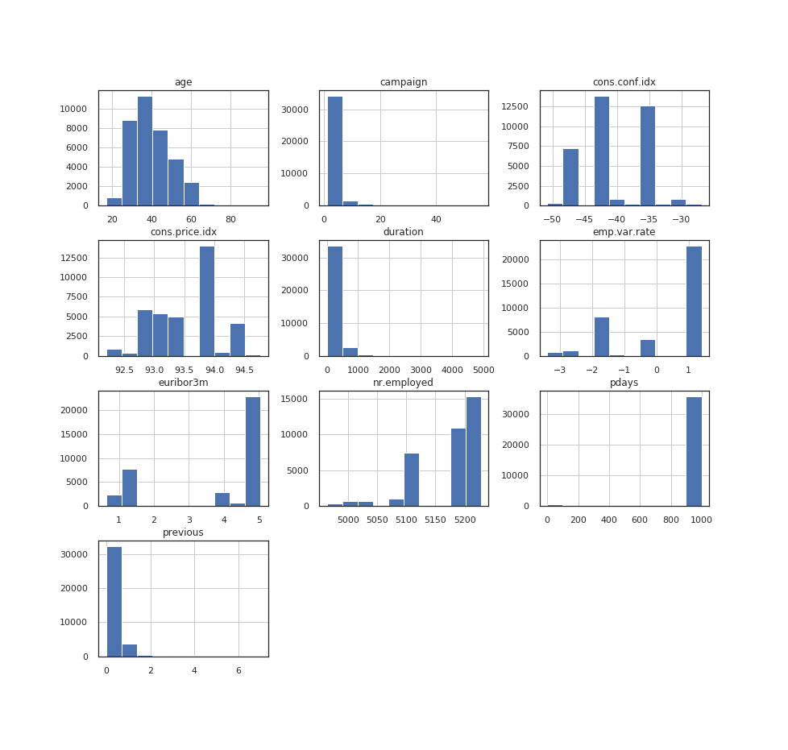

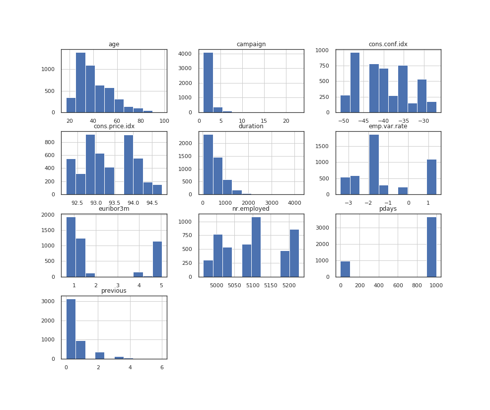

```
y
no     [[AxesSubplot(0.125,0.725918;0.215278x0.154082...
yes    [[AxesSubplot(0.125,0.725918;0.215278x0.154082...
dtype: object
```

```python
df_bank_full_data.groupby('y').hist()
```

```python
df_bank_full_data[df_bank_full_data.y=='yes'].day_of_week.value_counts(normalize=True)
```

```
thu    0.225216
tue    0.205388
wed    0.204526
mon    0.182543
fri    0.182328
Name: day_of_week, dtype: float64
```

```python
df_bank_full_data[df_bank_full_data.y=='no'].day_of_week.value_counts(normalize=True)
```

```
mon    0.209779
thu    0.207344
wed    0.196591
tue    0.195277
fri    0.191009
Name: day_of_week, dtype: float64
```

## Inferences from Marital status attribute

- As we can see distribution pattern for getting subscribe the term deposit is similar in both converging and non-converging cases.
- But for term-deposit subscription convergence 'Maried' and 'single' are dominating.

```python
df_bank_full_data[df_bank_full_data.y=='yes'].marital.value_counts(normalize=True)
```

```
married     0.545690
single      0.349138
divorced    0.102586
unknown     0.002586
Name: marital, dtype: float64
```

```python
df_bank_full_data[df_bank_full_data.y=='no'].marital.value_counts(normalize=True)
```

```
married     0.612783
single      0.272190
divorced    0.113166
unknown     0.001861
Name: marital, dtype: float64
```

## Inferences from Age status attribute

- Between 17-31 years of age clients are in majority in converging the term-deposit subscription.

```python
df_bank_full_data[df_bank_full_data.y=='yes'].age.describe()
```

```
count    4640.000000
mean       40.913147
std        13.837476
min        17.000000
25%        31.000000
50%        37.000000
75%        50.000000
max        98.000000
Name: age, dtype: float64
```

```python
df_bank_full_data['group_age'] = pd.cut(x=df_bank_full_data['age'], bins=[17, 31, 37, 50, 100], labels=['17-31', '31-37', '37-50', '50-100'])
```

```python
df_bank_full_data[df_bank_full_data.y=='yes']['group_age'].value_counts(normalize=True)
```

```
17-31     0.289349
37-50     0.253989
50-100    0.233290
31-37     0.223372
Name: group_age, dtype: float64
```

```python
df_bank_full_data['group_age'].value_counts(normalize=True)
```

```
37-50     0.345774
31-37     0.253454
17-31     0.226428
50-100    0.174344
Name: group_age, dtype: float64
```

```python
import jenkspy
jenkspy.jenks_breaks(df_bank_full_data.age, nb_class=4)
```

```
[17.0, 33.0, 42.0, 53.0, 98.0]
```

```python
duration_break = jenkspy.jenks_breaks(df_bank_full_data.duration, nb_class=4)
duration_break
```

```
[0.0, 227.0, 520.0, 1057.0, 4918.0]
```

```python
df_bank_full_data['group_duration'] = pd.cut(x=df_bank_full_data['duration'], bins=duration_break, labels=['0-227', '227-520', '520-1057', '1057-4918'])
```

```python
df_bank_full_data[df_bank_full_data.y=='yes'].group_duration.value_counts(dropna=False)
```

```
227-520      1666
520-1057     1534
0-227         952
1057-4918     488
Name: group_duration, dtype: int64
```

```python
df_bank_full_data.info()
```

[output not shown]

```python
jenkspy.jenks_breaks(df_bank_full_data.campaign, nb_class=4)
```

```
[1.0, 2.0, 6.0, 15.0, 56.0]
```

```python
jenkspy.jenks_breaks(df_bank_full_data.pdays, nb_class=4)
```

```
[0.0, 4.0, 9.0, 27.0, 999.0]
```

## Plotly dashboard visulization.

```python
import plotly
from plotly import tools
fig = tools.make_subplots(rows=2, cols=2, print_grid=True, vertical_spacing=0.085, subplot_titles=('Age', 'Marital', 'Job', 'Education'))
```

```
This is the format of your plot grid:
[ (1,1) x,y   ]  [ (1,2) x2,y2 ]
[ (2,1) x3,y3 ]  [ (2,2) x4,y4 ]
```

```python
import plotly.graph_objs as go
fig.add_trace(go.Histogram(histfunc="count", x=df_bank_full_data[df_bank_full_data.y=='yes'].group_age.tolist(), name="subscribed" ), 1, 1)
fig.add_trace(go.Histogram(histfunc="count", x=df_bank_full_data[df_bank_full_data.y=='no'].group_age.tolist(), name="not-subscribed" ), 1, 1)

fig.add_trace(go.Histogram(histfunc="count", x=df_bank_full_data[df_bank_full_data.y=='yes'].marital.tolist(), name="subscribed" ), 1, 2)
fig.add_trace(go.Histogram(histfunc="count", x=df_bank_full_data[df_bank_full_data.y=='no'].marital.tolist(), name="not-subscribed" ), 1, 2)


fig.add_trace(go.Histogram(histfunc="count", x=df_bank_full_data[df_bank_full_data.y=='yes'].job.tolist(), name="subscribed" ), 2, 1)
fig.add_trace(go.Histogram(histfunc="count", x=df_bank_full_data[df_bank_full_data.y=='no'].job.tolist(), name="not-subscribed" ), 2, 1)

fig.add_trace(go.Histogram(histfunc="count", x=df_bank_full_data[df_bank_full_data.y=='yes'].education.tolist(), name="subscribed" ), 2, 2)
fig.add_trace(go.Histogram(histfunc="count", x=df_bank_full_data[df_bank_full_data.y=='no'].education.tolist(), name="not-subscribed" ), 2, 2)
```

```
Histogram({
    'histfunc': 'count',
    'name': 'not-subscribed',
    'uid': '6da66caa-4942-40c6-902d-01e3594bfd56',
    'x': [basic.4y, high.school, high.school, ..., professional.course,
          university.degree, professional.course],
    'xaxis': 'x4',
    'yaxis': 'y4'
})
```

```python
plotly.offline.plot(fig, filename='../static/dashboard_first_chart1.html')
```

[output not shown]

```python
import plotly.graph_objs as go

fig = tools.make_subplots(rows=2, cols=2, print_grid=True, vertical_spacing=0.085, subplot_titles=('Loan', 'Housing_loan', 'Month', 'Day_of_week'))
fig.add_trace(go.Histogram(histfunc="count", x=df_bank_full_data[df_bank_full_data.y=='yes'].loan.tolist(), name="subscribed" ), 1, 1)
fig.add_trace(go.Histogram(histfunc="count", x=df_bank_full_data[df_bank_full_data.y=='no'].loan.tolist(), name="not-subscribed" ), 1, 1)

fig.add_trace(go.Histogram(histfunc="count", x=df_bank_full_data[df_bank_full_data.y=='yes'].housing.tolist(), name="subscribed" ), 1, 2)
fig.add_trace(go.Histogram(histfunc="count", x=df_bank_full_data[df_bank_full_data.y=='no'].housing.tolist(), name="not-subscribed" ), 1, 2)


fig.add_trace(go.Histogram(histfunc="count", x=df_bank_full_data[df_bank_full_data.y=='yes'].month.tolist(), name="subscribed" ), 2, 1)
fig.add_trace(go.Histogram(histfunc="count", x=df_bank_full_data[df_bank_full_data.y=='no'].month.tolist(), name="not-subscribed" ), 2, 1)

fig.add_trace(go.Histogram(histfunc="count", x=df_bank_full_data[df_bank_full_data.y=='yes'].day_of_week.tolist(), name="subscribed" ), 2, 2)
fig.add_trace(go.Histogram(histfunc="count", x=df_bank_full_data[df_bank_full_data.y=='no'].day_of_week.tolist(), name="not-subscribed" ), 2, 2)
```

```
This is the format of your plot grid:
[ (1,1) x1,y1 ]  [ (1,2) x2,y2 ]
[ (2,1) x3,y3 ]  [ (2,2) x4,y4 ]
```

```
Histogram({
    'histfunc': 'count',
    'name': 'not-subscribed',
    'uid': '96519f72-17e0-4860-a1c1-bbcecf69ff40',
    'x': [mon, mon, mon, ..., fri, fri, fri],
    'xaxis': 'x4',
    'yaxis': 'y4'
})
```

```python
plotly.offline.plot(fig, filename='../static/dashboard_first_chart2.html')
```

```
'../static/dashboard_first_chart2.html'
```

```python
import plotly.graph_objs as go

fig = tools.make_subplots(rows=7, cols=1, print_grid=True, vertical_spacing=0.085, subplot_titles=('duration', 'age', 'euribor3m', 'pdays', 'cons.price.idx', 'cons.conf.idx', 'nr.employed'))
fig.add_trace(go.Box(x=df_bank_full_data[df_bank_full_data.y=='yes'].duration.tolist(), name="subscribed" ), 1, 1)
fig.add_trace(go.Box(x=df_bank_full_data[df_bank_full_data.y=='yes'].age.tolist(), name="subscribed" ), 2, 1)
fig.add_trace(go.Box(x=df_bank_full_data[df_bank_full_data.y=='yes'].euribor3m.tolist(), name="subscribed" ), 3, 1)
fig.add_trace(go.Box(x=df_bank_full_data[df_bank_full_data.y=='yes'].pdays.tolist(), name="subscribed" ), 4, 1)
fig.add_trace(go.Box(x=df_bank_full_data[df_bank_full_data.y=='yes']['cons.price.idx'].tolist(), name="subscribed" ), 5, 1)
fig.add_trace(go.Box(x=df_bank_full_data[df_bank_full_data.y=='yes']['cons.conf.idx'].tolist(), name="subscribed" ), 6, 1)
fig.add_trace(go.Box(x=df_bank_full_data[df_bank_full_data.y=='yes']['nr.employed'].tolist(), name="subscribed" ), 7, 1)
```

```
This is the format of your plot grid:
[ (1,1) x,y   ]
[ (2,1) x2,y2 ]
[ (3,1) x3,y3 ]
[ (4,1) x4,y4 ]
[ (5,1) x5,y5 ]
[ (6,1) x6,y6 ]
[ (7,1) x7,y7 ]
```

[interactive chart not shown]

```python
plotly.offline.plot(fig, filename='../static/dashboard_first_chart3.html')
```

```
'../static/dashboard_first_chart3.html'
```

## Month wise dostribution

```python
df_bank_full_data["Month"] = df_bank_full_data.month.str.capitalize()
```

```python
df_bank_full_data["Month"] = pd.to_datetime(df_bank_full_data.Month, format='%b', errors='coerce').dt.month_name()
```

```python
df_bank_full_data = df_bank_full_data.sort_values(by="Month")
```

```python
df_bank_full_data.groupby('Month').count()
```

| Month | age | job | marital | education | default | housing | loan | contact | month | day_of_week | ... | pdays | previous | poutcome | emp.var.rate | cons.price.idx | cons.conf.idx | euribor3m | nr.employed | y | group_age |
| --- | --- | --- | --- | --- | --- | --- | --- | --- | --- | --- | --- | --- | --- | --- | --- | --- | --- | --- | --- | --- | --- |
| April | 2632 | 2632 | 2632 | 2632 | 2632 | 2632 | 2632 | 2632 | 2632 | 2632 | ... | 2632 | 2632 | 2632 | 2632 | 2632 | 2632 | 2632 | 2632 | 2632 | 2632 |
| August | 6178 | 6178 | 6178 | 6178 | 6178 | 6178 | 6178 | 6178 | 6178 | 6178 | ... | 6178 | 6178 | 6178 | 6178 | 6178 | 6178 | 6178 | 6178 | 6178 | 6174 |
| December | 182 | 182 | 182 | 182 | 182 | 182 | 182 | 182 | 182 | 182 | ... | 182 | 182 | 182 | 182 | 182 | 182 | 182 | 182 | 182 | 182 |
| July | 7174 | 7174 | 7174 | 7174 | 7174 | 7174 | 7174 | 7174 | 7174 | 7174 | ... | 7174 | 7174 | 7174 | 7174 | 7174 | 7174 | 7174 | 7174 | 7174 | 7174 |
| June | 5318 | 5318 | 5318 | 5318 | 5318 | 5318 | 5318 | 5318 | 5318 | 5318 | ... | 5318 | 5318 | 5318 | 5318 | 5318 | 5318 | 5318 | 5318 | 5318 | 5318 |
| March | 546 | 546 | 546 | 546 | 546 | 546 | 546 | 546 | 546 | 546 | ... | 546 | 546 | 546 | 546 | 546 | 546 | 546 | 546 | 546 | 546 |
| May | 13769 | 13769 | 13769 | 13769 | 13769 | 13769 | 13769 | 13769 | 13769 | 13769 | ... | 13769 | 13769 | 13769 | 13769 | 13769 | 13769 | 13769 | 13769 | 13769 | 13769 |
| November | 4101 | 4101 | 4101 | 4101 | 4101 | 4101 | 4101 | 4101 | 4101 | 4101 | ... | 4101 | 4101 | 4101 | 4101 | 4101 | 4101 | 4101 | 4101 | 4101 | 4101 |
| October | 718 | 718 | 718 | 718 | 718 | 718 | 718 | 718 | 718 | 718 | ... | 718 | 718 | 718 | 718 | 718 | 718 | 718 | 718 | 718 | 717 |
| September | 570 | 570 | 570 | 570 | 570 | 570 | 570 | 570 | 570 | 570 | ... | 570 | 570 | 570 | 570 | 570 | 570 | 570 | 570 | 570 | 570 |

10 rows × 22 columns

```python
import plotly.graph_objs as go

df_month_y = df_bank_full_data[df_bank_full_data.y=='yes'].groupby('Month').count().reset_index()
df_month_n = df_bank_full_data[df_bank_full_data.y=='no'].groupby('Month').count().reset_index()
fig = tools.make_subplots(rows=2, cols=1, print_grid=True, vertical_spacing=0.085, subplot_titles=('Subscribed', 'Not-Subscribed'))
fig.add_trace(go.Scatter(x=df_month_y['Month'], y=df_month_y['y'], name="subscribed"), 1, 1)
fig.add_trace(go.Scatter(x=df_month_n['Month'], y=df_month_n['y'], name="not-subscribed"), 2, 1)
plotly.offline.plot(fig, filename='../static/dashboard_first_chart4.html')
```

```
This is the format of your plot grid:
[ (1,1) x,y   ]
[ (2,1) x2,y2 ]
```

```
'../static/dashboard_first_chart4.html'
```